Assignment for the Practical Machine Learning Course Published on 27/09/2015 By Lupo Argentato (Facebook Pseudo) alias Gianluca BUONAMICO

STEP 1: What is the question?

Data from a sample of 6 people using accelerometers on the belt, forearm, arm, and dumbell are used to understand how well they are performing compared to a 'witness' group of professionnals store in A group

From collected observations, the aim is to buld a predictive model that will assess how well the exercise is done and rank in the right group, from A to E #

STEP 2 : LOAD AND ANALYSE DATA

```r
##

# load relevant libraries
library(caret)
library(ISLR); library(ggplot2);
# Create 1 datasets reading the CSV file
# We will Use this dataset both for training(70%) and testing(30%) purpose.
#
inDatasetHAR<-read.csv(file="pml-training.csv",head=TRUE,sep=",")
inDatasetValidHAR<-read.csv(file="pml-testing.csv",head=TRUE,sep=",")
#
```

This is the data file that Velloso, E.; Bulling, A.; Gellersen, H.; Ugulino, W.; Fuks, H. use in thei paper “Qualitative Activity Recognition of Weight Lifting Exercises. Proceedings of 4th International Conference in Cooperation with SIGCHI (Augmented Human '13) . Stuttgart, Germany: ACM SIGCHI, 2013.

Read more: http://groupware.les.inf.puc-rio.br/har#ixzz3mvTxcXYG

Now Load data and store in two different datasets, for training and testing purpose

```r
inTrainTest <- createDataPartition(y=inDatasetHAR$classe,p=0.7, list=FALSE)
#70% of data for training and tests
#Now Split in training and testing dataset (70% 30%)
trainingHAR<-inDatasetHAR[inTrainTest,]
testingHAR<-inDatasetHAR[-inTrainTest,]
```

So we choose to have a training SET for 70% of data and 30% for testing. The dataset contains 19622 observations and 160 variables. First 7 variables are probably not relevant (name, ID line, Window…). So we throw them out

```r
d<-dim(trainingHAR)
trainingHAR<-trainingHAR[,8:d[2]]
testingHAR<-testingHAR[,8:d[2]]
```

Analysis of training dataset : a lot of variable with "MISSING values”, and variables with zero variance we can consider these as “poor” predictors

```r
# Eliminates zero Variance predictors..
nearZeroVar(trainingHAR,saveMetrics=TRUE)
```

[output not shown]

[output cut: 99 more lines]

```
## stddev_pitch_forearm       56.000000    1.57239572   FALSE  TRUE
## var_pitch_forearm          56.000000    1.57239572   FALSE  TRUE
## avg_yaw_forearm            56.000000    1.57239572   FALSE  TRUE
## stddev_yaw_forearm         57.000000    1.56511611   FALSE  TRUE
## var_yaw_forearm            57.000000    1.56511611   FALSE  TRUE
## gyros_forearm_x             1.063361    2.05284997   FALSE FALSE
## gyros_forearm_y             1.058140    5.27043750   FALSE FALSE
## gyros_forearm_z             1.097701    2.14020528   FALSE FALSE
## accel_forearm_x             1.015625    5.66353643   FALSE FALSE
## accel_forearm_y             1.000000    7.08306035   FALSE FALSE
## accel_forearm_z             1.018349    4.06930189   FALSE FALSE
## magnet_forearm_x            1.083333   10.54087501   FALSE FALSE
## magnet_forearm_y            1.192982   13.32168596   FALSE FALSE
## magnet_forearm_z            1.023256   11.76384946   FALSE FALSE
## classe                      1.469526    0.03639805   FALSE FALSE
```

```r
nsv<-nearZeroVar(trainingHAR)
trainingHAR<- trainingHAR[, -nsv]
testingHAR<-testingHAR[,-nsv]
```

Variable with missing values are also frequent. We measur the quantity of these NA values and put a threshold to 90%. Then we will keep only variables with less than 90% of NA values

```r
##
## Then eliminates predictors with imprtant percentage of missing values (>90%)
##
##
na_count <-sapply(trainingHAR, function(y) sum(length(which(is.na(y)))))
na_perc=na_count/dim(trainingHAR)
reducedTrainingHAR<-trainingHAR[, na_perc <= 0.9]
reducedTestingHAR<-testingHAR[, na_perc <= 0.9]
```

STEP 3 The Algorythm

Random Forest used with cross validation seems to be a good approach, because the class of alghorithm fit well this kind of classification problem, bootstrap and cross validation are also easy to use. We can estimate how the number of predictors will influence the error of the model using the rfcv,randomForest or train function in caret. the differences are in execution time and output variables, and the use with the varImp output to estimate importances of predictors and errors outputs. The train function is the most time consuming.

```r
# set seed value and parallel options
set.seed(125)
doMC::registerDoMC(cores=4)
library(MASS)
library(randomForest)
library(class)

#FitModel <- rfcv(reducedTrainingHAR[,1:(dim(reducedTrainingHAR)[2]-1)],reducedTrainingHAR[#,dim(reducedTrainingHAR)[2]],cv.fold=5,mtry=function(p) max(1, floor(sqrt(p))), #recursive=TRUE)

#
# Alternatively, we can use this
#FitModel0 <- randomForest(reducedTrainingHAR[,1:(dim(reducedTrainingHAR)[2]-1)],reducedTrainingHAR[,dim(reducedTrainingHAR)[2]],cv.fold=5, importance=TRUE)
#FitModel2 <- train(classe ~ ., #method="rf",data=reducedTrainingHAR,trControl=trainControl(method="cv",number=5),prox=TRUE#,importance=TRUE,allowParallel=TRUE)
#
```

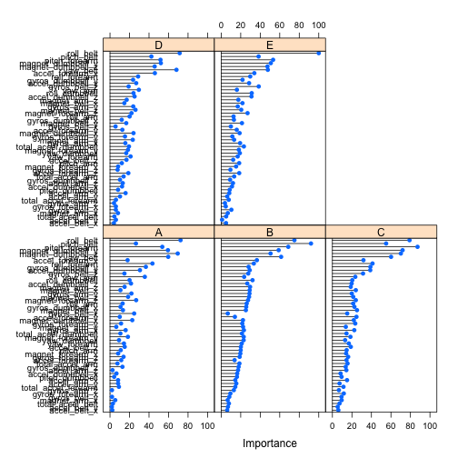

```r
plot(varImp(FitModel2))
```

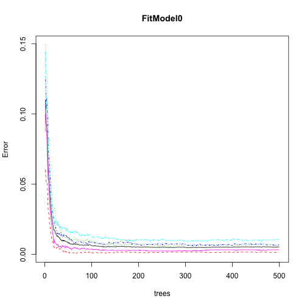

```r
#
#
#
plot(FitModel0)
```

```r
# print the nb of selected predictors and the accuracy

FitModel$error.cv
```

```
##          52          26          13           6           3           1
## 0.006988425 0.008517143 0.080366892 0.117638495 0.148504040 0.474776152
```

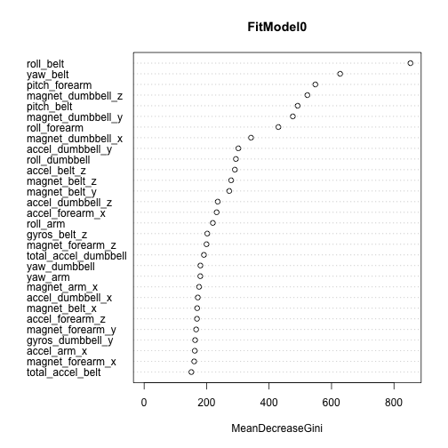

```r
# also print the most important predictors
varImpPlot(FitModel0,type=2)
```

```r
#varImp(FitModel0)
```

The model result shows a high accuracy in the training set.

```r
FitModel2
```

```
## Random Forest
##
## 13737 samples
##    52 predictor
##     5 classes: 'A', 'B', 'C', 'D', 'E'
##
## No pre-processing
## Resampling: Cross-Validated (5 fold)
## Summary of sample sizes: 10989, 10991, 10989, 10991, 10988
## Resampling results across tuning parameters:
##
##   mtry  Accuracy   Kappa      Accuracy SD  Kappa SD
##    2    0.9910469  0.9886739  0.002960099  0.003745062
##   27    0.9913375  0.9890407  0.001824816  0.002309775
##   52    0.9855129  0.9816717  0.003170484  0.004012370
##
## Accuracy was used to select the optimal model using  the largest value.
## The final value used for the model was mtry = 27.
```

STEP4 EVALUATION

Lets try it on the testing set and use confusion matrix to assess the score

```r
resu<-confusionMatrix(reducedTestingHAR$classe, predict(FitModel2, reducedTestingHAR))
resu
```

```
## Confusion Matrix and Statistics
##
##           Reference
## Prediction    A    B    C    D    E
##          A 1674    0    0    0    0
##          B    1 1136    2    0    0
##          C    0    2 1024    0    0
##          D    0    0    5  959    0
##          E    0    0    0    1 1081
##
## Overall Statistics
##
##                Accuracy : 0.9981
##                  95% CI : (0.9967, 0.9991)
##     No Information Rate : 0.2846
##     P-Value [Acc > NIR] : < 2.2e-16
##
##                   Kappa : 0.9976
##  Mcnemar's Test P-Value : NA
##
## Statistics by Class:
##
##                      Class: A Class: B Class: C Class: D Class: E
## Sensitivity            0.9994   0.9982   0.9932   0.9990   1.0000
## Specificity            1.0000   0.9994   0.9996   0.9990   0.9998
## Pos Pred Value         1.0000   0.9974   0.9981   0.9948   0.9991
## Neg Pred Value         0.9998   0.9996   0.9986   0.9998   1.0000
## Prevalence             0.2846   0.1934   0.1752   0.1631   0.1837
## Detection Rate         0.2845   0.1930   0.1740   0.1630   0.1837
## Detection Prevalence   0.2845   0.1935   0.1743   0.1638   0.1839
## Balanced Accuracy      0.9997   0.9988   0.9964   0.9990   0.9999
```

```r
z<-as.table(resu)
z
```

```
##           Reference
## Prediction    A    B    C    D    E
##          A 1674    0    0    0    0
##          B    1 1136    2    0    0
##          C    0    2 1024    0    0
##          D    0    0    5  959    0
##          E    0    0    0    1 1081
```

```r
# try also a heatmap but not really nice
# colnames(z) = c("A","B","C","D","E")
# rownames(z)=colnames(z)
# image(z[,ncol(z):1], axes=FALSE)
# heatmap(t(z)[ncol(z):1,], Rowv=NA,Colv=NA, col = heat.colors(256))
#
```

Balanced accuracy is really nice.

```r
outdata20<-inDatasetValidHAR[,8:d[2]]
outdata20<-outdata20[,-nsv]
outdata20<-outdata20[, na_perc <= 0.9]
#predict20=predict(FitModel,outdata20)
#predict20
```